# FD models

Knit on

November 14, 2026

# 1 Setup

```r
library(conflicted)
library(tidyverse)
library(tidybayes)
library(distributional)
library(brms)
library(ggdist)
library(bayesplot)
library(patchwork)
library(DT)

source("functions.R")

conflicts_prefer(dplyr::filter,
                 stats::lag,
                 distributional::parameters,
                 brms::ar,
                 brms::dstudent_t,
                 brms::pstudent_t,
                 brms::qstudent_t,
                 brms::rstudent_t,
                 brms::rhat)

options(mc.cores = parallel::detectCores())
options(brms.file_refit = "on_change")
options(brms.backend = "cmdstanr")
options(contrasts = c("contr.sum", "contr.poly"))
options(digits = 3)

set.seed(2058)

if (!dir.exists("fits/fd")) dir.create("fits/fd", recursive = T)
if (!dir.exists("fits/extra")) dir.create("fits/extra", recursive = T)

theme_set(theme_minimal())

load("intermediate/SES.RData")
load("intermediate/weather.RData")

show <- vars(!c(lprior, lp__, b_Intercept))
```

# 2 Preparing the FD data

```r
#unrestricted SES
results_all <- results_all |>
  mutate(across(date:subplot, as_factor)) |>
  rename(year = date, site = plot)
datatable(results_all)
```

|  | year | site | subplot | overall | above | below |
| --- | --- | --- | --- | --- | --- | --- |
| 1 | 1999 | 01-ABR1 | 1 | -2.276014711039953 | -1.643431833162951 | -1.629971545920519 |
| 2 | 1999 | 01-ABR1 | 13 | 0.5031743196662588 | 0.8401642448549329 | 0.09032215951129728 |
| 3 | 1999 | 01-ABR1 | 14 | -0.7418300900232365 | -0.4116310007278601 | -0.6277665114574271 |
| 4 | 1999 | 01-ABR1 | 15 | -0.2850386824211168 | 0.7112933565322521 | -0.7902905743745813 |
| 5 | 1999 | 01-ABR1 | 19 | -1.899415859825762 | -2.684508739987379 | -0.5501542850087502 |
| 6 | 1999 | 01-ABR1 | 22 | 0.7624558992957138 | 0.9091652756870076 | 0.4058069186010059 |
| 7 | 1999 | 01-ABR1 | 23 | -0.04190919700146369 | -0.9239167299596036 | 0.6080707793764802 |
| 8 | 1999 | 03-CAL1 | 1 | 1.001014743554301 | 2.162584281838085 | -0.09841606930570064 |
| 9 | 1999 | 03-CAL1 | 2 | 1.271500928686211 | 1.598109609721869 | 0.5375097759777709 |
| 10 | 1999 | 03-CAL1 | 3 | 2.23213272607455 | 1.421230466005782 | 1.75052339878289 |

[output cut: 472 more lines]

```r
#regional pool
results_sites <- results_sites |>
  mutate(across(date:subplot, as_factor)) |>
  rename(year = date, site = plot)
datatable(results_sites)
```

|  | year | site | subplot | overall | above | below |
| --- | --- | --- | --- | --- | --- | --- |
| 1 | 1999 | 01-ABR1 | 1 | -2.102587305586149 | -1.047872462043901 | -1.916172548906863 |
| 2 | 1999 | 01-ABR1 | 13 | 0.8862351645614217 | 2.227231476523492 | -0.04427870958077499 |
| 3 | 1999 | 01-ABR1 | 14 | 0.1733126288062256 | 2.486430355722086 | -0.9975268435014477 |
| 4 | 1999 | 01-ABR1 | 15 | 0.4044698252698836 | 2.818000425757171 | -0.8694184222521625 |
| 5 | 1999 | 01-ABR1 | 19 | -1.669541034808955 | -1.981893229931816 | -1.095497857150149 |
| 6 | 1999 | 01-ABR1 | 22 | 1.034289491271028 | 2.078685694566594 | 0.2174399725651874 |
| 7 | 1999 | 01-ABR1 | 23 | 0.4883008097545778 | 0.004669893690149432 | 0.4426736444440899 |
| 8 | 2000 | 01-ABR1 | 13 | 0.8700671520210195 | 2.213509306546113 | -0.05241968010894665 |
| 9 | 2000 | 01-ABR1 | 15 | 0.8906632881186652 | 2.047737748632952 | 0.0728840411326846 |
| 10 | 2000 | 01-ABR1 | 19 | -2.325384288406965 | -3.116393921708287 | -1.087488361922414 |

[output cut: 472 more lines]

```r
#temporal pool
results_years <- results_years |>
  mutate(across(date:subplot, as_factor)) |>
  rename(year = date, site = plot)
datatable(results_years)
```

|  | year | site | subplot | overall | above | below |
| --- | --- | --- | --- | --- | --- | --- |
| 1 | 1999 | 01-ABR1 | 1 | -2.191741282521168 | -1.268806441924899 | -1.805760895566675 |
| 2 | 1999 | 01-ABR1 | 13 | 0.6706693677014357 | 0.9534733228545049 | 0.1496520231665691 |
| 3 | 1999 | 01-ABR1 | 14 | -0.2365702662019037 | 0.35416698832493 | -0.5688425444081313 |
| 4 | 1999 | 01-ABR1 | 15 | 0.1441153680763318 | 1.077348876603111 | -0.6621813987864533 |
| 5 | 1999 | 01-ABR1 | 19 | -1.854934072178071 | -2.492746671541692 | -0.7025011866451274 |
| 6 | 1999 | 01-ABR1 | 22 | 0.8350835941225199 | 0.9315328205404236 | 0.3909377213398301 |
| 7 | 1999 | 01-ABR1 | 23 | 0.2558870145403658 | -0.6387358822848445 | 0.7870117736886022 |
| 8 | 1999 | 03-CAL1 | 1 | 1.620746169718168 | 2.985491485719386 | -0.1302215521424828 |
| 9 | 1999 | 03-CAL1 | 2 | 1.814462477820044 | 2.272969739881721 | 0.5929003063338475 |
| 10 | 1999 | 03-CAL1 | 3 | 2.773790195127734 | 1.946479462042143 | 2.01465698744456 |

[output cut: 472 more lines]

# 3 Join canopy cover

Canopy cover percentage is scaled in the range 0-4, so that the prior for the regression coefficient corresponds to an increase of 25% in canopy cover, and zero (no canopy cover) is kept as reference value. This allows the use of the same prior as for the other effects, which speeds up computation.

```r
cover <- read_csv("Data/cover.csv") |>
  mutate(year = as_factor(year),
         site = as_factor(site),
         #cover as proportion 0-4
         cover = cover / 100 * 4)

add_cover <- function(y) y |>
  map(\(x) x |> left_join(cover))

data_ITP_above <- add_cover(data_ITP_above)

data_ITP_below <- add_cover(data_ITP_below)

data_ITP_overall <- add_cover(data_ITP_overall)
```

# 4 Priors

The choice of priors has been discussed in the simulation notebook, here are just the distributions. It is important to remember that the prior of the intercept applies after all predictors are centered, so all priors refer to deviations from the mean. In this case, the predictor is scaled by its standard deviation, before deriving the other predictors (site mean, mean-centered predictor), so the slope coefficients can be interpreted in terms of standard deviations of the predictor. Since the output is a SES, we expect the range to be roughly [-2, 2]. We can see that these priors are wide, but most of the probability is on smaller values.

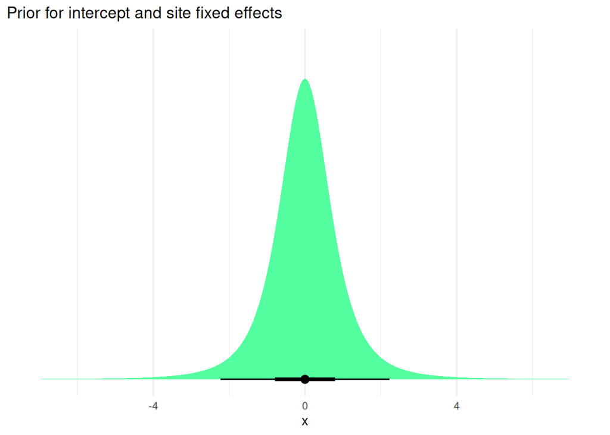

```r
ggplot()+
  stat_halfeye(aes(xdist = dist_student_t(3, 0, 0.7)),
    fill = "seagreen1", .width = c(0.66, 0.95))+
  scale_y_continuous(NULL, breaks = NULL)+
  ggtitle("Prior for intercept and site fixed effects")
```

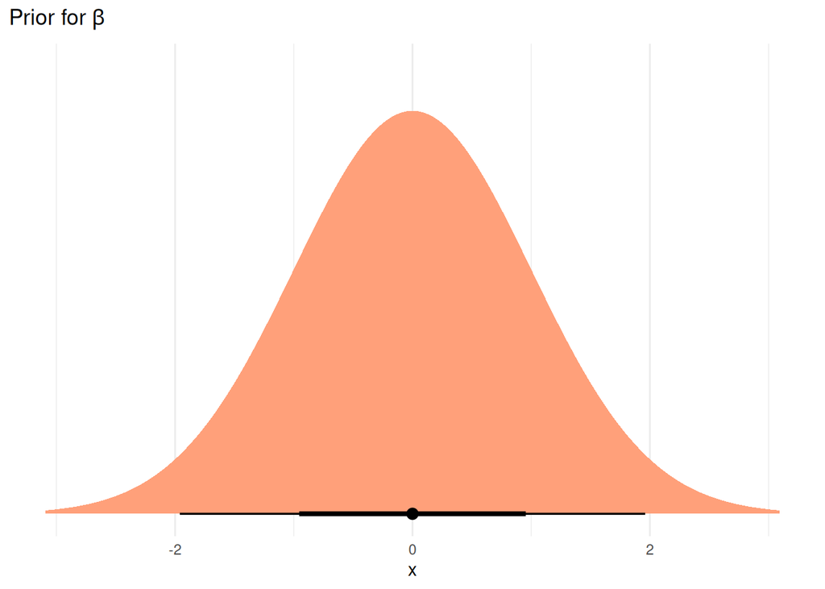

```r
ggplot()+
  stat_halfeye(aes(xdist = dist_normal(0, 1)),
    fill = "lightsalmon", .width = c(0.66, 0.95))+
  scale_y_continuous(NULL, breaks = NULL)+
  ggtitle(expression("Prior for"~beta))
```

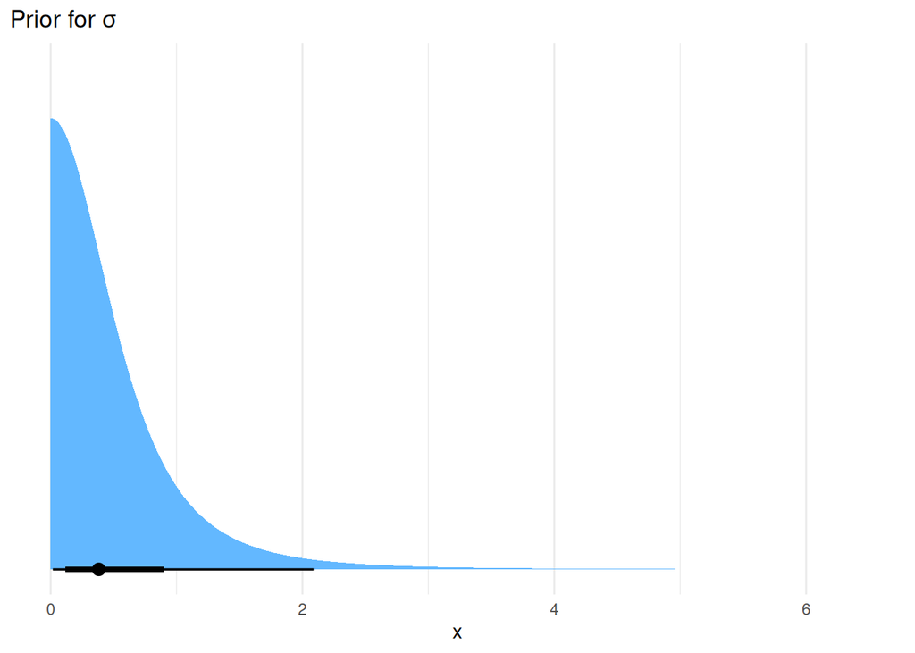

```r
ggplot()+
  stat_halfeye(aes(xdist = dist_truncated(dist_student_t(3, 0, 0.5), lower = 0)),
                fill = "steelblue1", .width = c(0.66, 0.95))+
  scale_y_continuous(NULL, breaks = NULL)+
  ggtitle(expression("Prior for"~sigma))
```

```r
prior <- c(prior(student_t(3, 0, 0.7), class = "Intercept"),
           prior(normal(0, 1), class = "b"),
           prior(student_t(3, 0, 0.7), class = "b", coef = "site1"),
           prior(student_t(3, 0, 0.7), class = "b", coef = "site2"),
           prior(student_t(3, 0, 0.7), class = "b", coef = "site3"),
           prior(student_t(3, 0, 0.5), class = "sigma", lb = 0))

#itp has only three sites
prior_itp <- prior |>
  filter_out(coef == "site3")

#soil_t_ofd has only two sites
prior_soil <- prior_itp |>
  filter_out(coef == "site2")
```

Prior predictive simulation of the expected values:

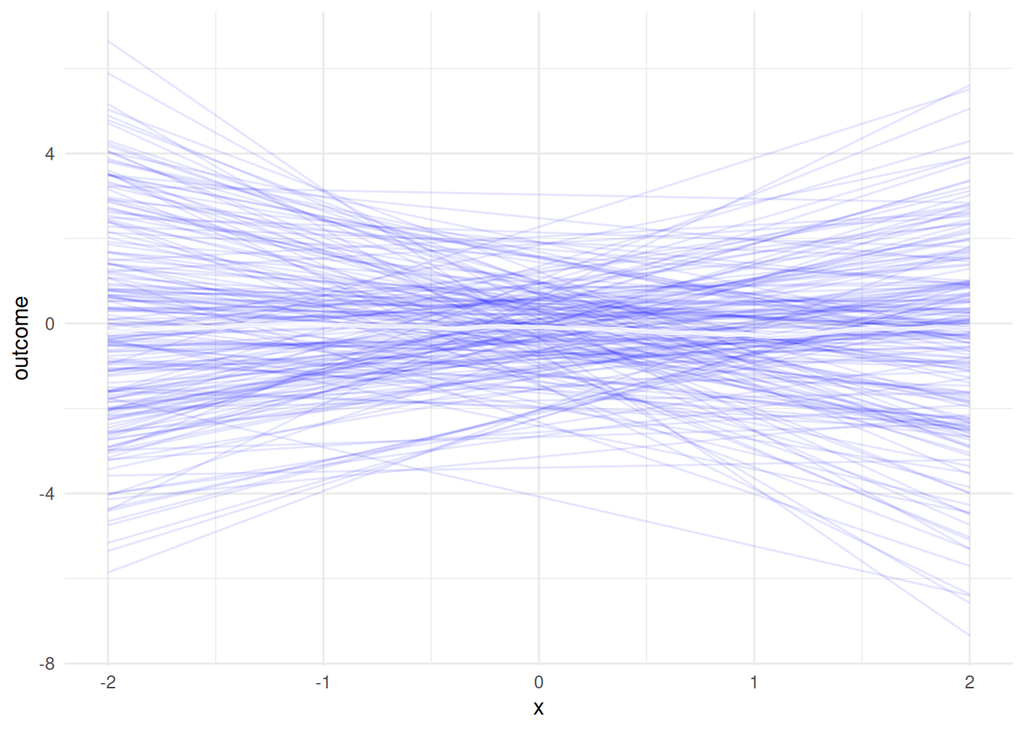

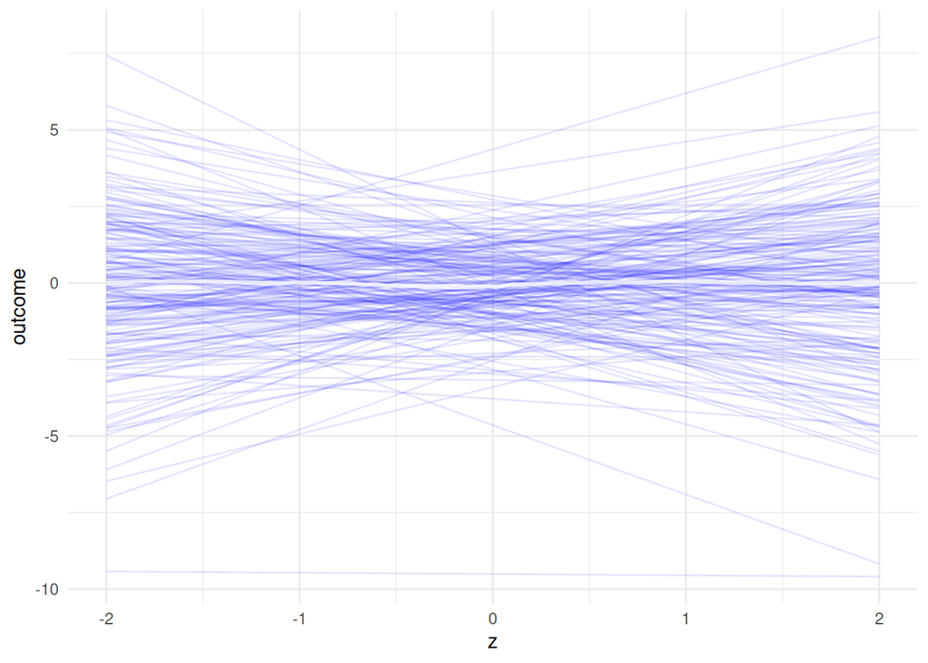

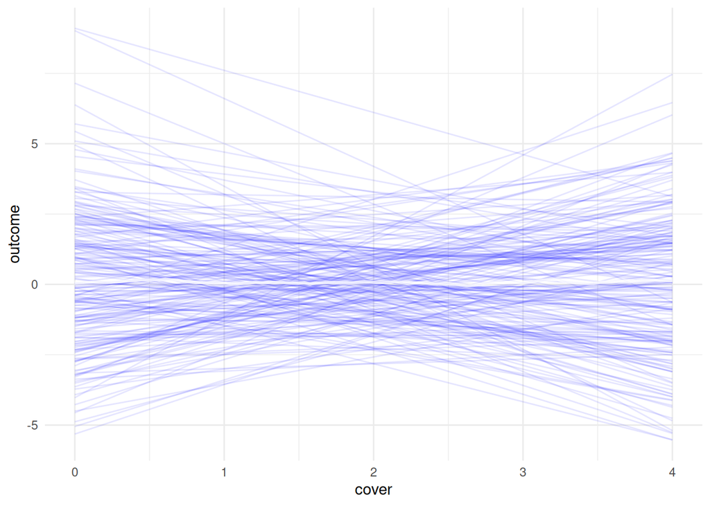

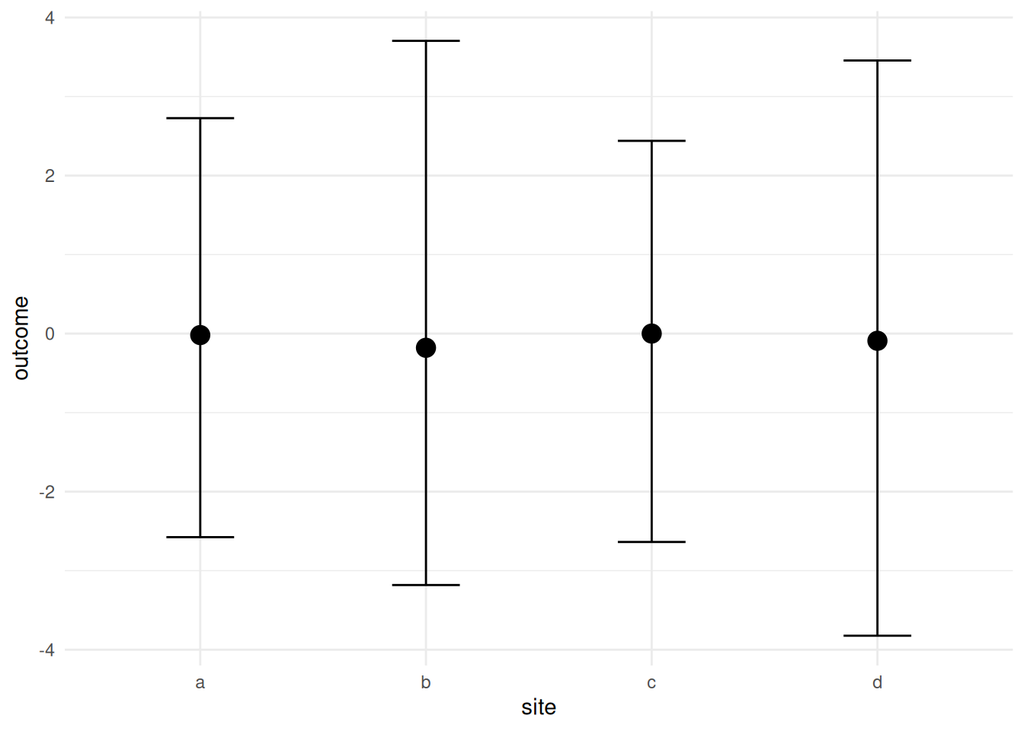

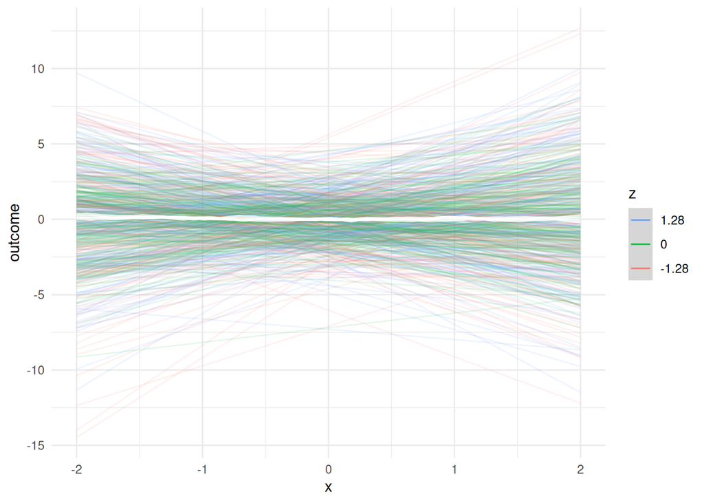

```r
#since it's sampling only the prior, these are just to give a reference for the plot
data_prior <- tibble(outcome = 0,
                     x = seq(-2, 2, length.out = 10),
                     cover = seq(0, 4, length.out = 10)) |>
  expand_grid(z = seq(-2, 2, length.out = 10),
              site = letters[1:4])

prior_pred <- brm(outcome ~ x + z + x:z + cover + site,
             data = data_prior,
             sample_prior = "only",
             prior = prior,
             file = "fits/prior_fd",
             seed = 2853)

conditional_effects(prior_pred,
                    spaghetti = T,
                    ndraws = 200) |>
  plot(ask = F)
```

# 5 Prepare data

The following functions process the variables for modeling. Weather data is scaled by a representative value instead of the exact standard deviation in each dataset to have a consistent value across datasets, and this is stored alongside data. The site grand means are calculated and subtracted to obtain separate within and between site variations. This also makes the models fit more easily because the within-site effect parameters are uncorrelated with the site intercepts.

```r
variables <- c("air_t_mean", "soil_t_mean", "precipitation")

imap(data_OFD,
     \(x, idx) x |>
       summarise("{idx}" := sd(.data[[idx]]))) |>
  bind_cols() |>
  select(any_of(setdiff(variables, "soil_t_mean")))
```

| air_t_mean | precipitation |
| --- | --- |
| 2.21 | 679 |

```r
data_ITP_overall |>
  map(\(x) x |>
        summarise(across(any_of(variables), sd))) |>
  bind_rows() |>
  summarise(across(everything(), mean))
```

| air_t_mean | soil_t_mean | precipitation |
| --- | --- | --- |
| 2.59 | 2.34 | 546 |

```r
data_ITP_above |>
  map(\(x) x |>
        summarise(across(any_of(variables), sd))) |>
  bind_rows() |>
  summarise(across(everything(), mean))
```

| air_t_mean | soil_t_mean | precipitation |
| --- | --- | --- |
| 2.57 | 2.33 | 570 |

```r
data_ITP_below |>
  map(\(x) x |>
        summarise(across(any_of(variables), sd))) |>
  bind_rows() |>
  summarise(across(everything(), mean))
```

| air_t_mean | soil_t_mean | precipitation |
| --- | --- | --- |
| 2.59 | 2.34 | 569 |

The standard deviations are roughly 2.5° C for temperature and 600 mm for precipitation. These are the representative values that will be used for scaling.

```r
sds <- c(2.5, 2.5, 600) |>
  set_names(variables)

prepare <- function(data, vars = variables) {
  data |>
    mutate(across(any_of(vars),
                  \(x) sds[[cur_column()]],
                  .names = "{.col}_sd"),
           across(any_of(vars),
                  \(x) x / sds[[cur_column()]])) |>
    # calculate site means
    mutate(across(any_of(vars), mean,
                  .names = "{.col}_site"),
           across(any_of(vars),
                  \(x) x - get(str_c(cur_column(), "_site")),
                  .names = "{.col}_centered"),
           .by = site)
}
```

## 5.1 OFD

```r
ofd <- inner_join(data_OFD$air_t_mean, data_OFD$precipitation) |>
  prepare()
```

## 5.2 ITP

```r
above_itp <- data_ITP_above |>
  map(prepare)

below_itp <- data_ITP_below |>
  map(prepare)

overl_itp <- data_ITP_overall |>
  map(prepare)
```

# 6 Years included in the models

```r
#these three datasets are sufficient to identify all subsets of years
years_across <- ofd |>
  select(year) |>
  bind_rows(above_itp[[1]] |>
            select(year)) |>
  distinct(year) |>
  mutate(year = as.character(year)) |>
  arrange(year) |>
  pull()
```

This corresponds to a timespan of 12 years.

## 6.1 By model

The years in each model:

```r
#OFD
ofd |>
  distinct(year)
```

| year |
| --- |
| 2001 |
| 2002 |
| 2006 |
| 2011 |
| 2005 |
| 2008 |

```r
#ITP
above_itp[[1]] |>
  distinct(year)
```

| year |
| --- |
| 2000 |
| 2001 |
| 2002 |
| 2005 |
| 2006 |
| 2008 |
| 2011 |

The number of site-year combinations:

```r
ofd |>
  distinct(site, year) |>
  nrow()
```

```
[1] 18
```

```r
above_itp[[1]] |>
  distinct(site, year) |>
  nrow()
```

```
[1] 21
```

# 7 Plotting FD-SES

Before modelling, it would be useful to check the distributions of FD-SES. All three randomizations are shown, although the models will focus on the randomization using the local species pool.

## 7.1 Unrestricted randomization

Overall, by year:

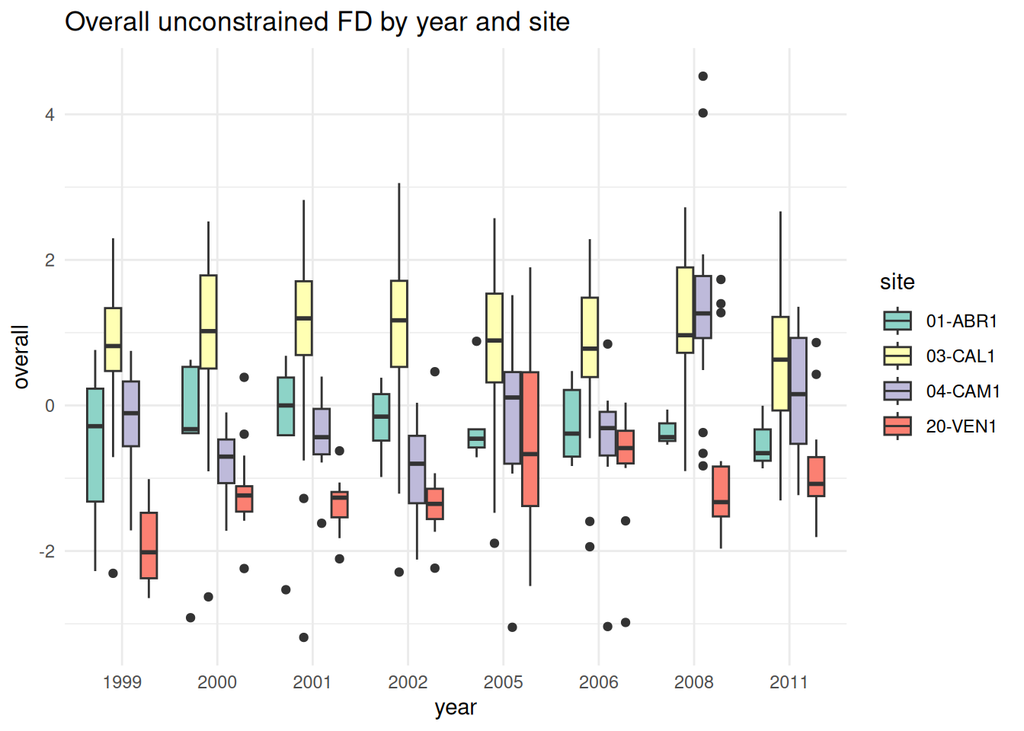

```r
results_all |>
  ggplot(aes(x = year, y = overall, fill = site)) +
  geom_boxplot() +
  scale_fill_brewer(type = "qual", palette = 8)+
  theme_minimal()+
  ggtitle("Overall unconstrained FD by year and site")
```

Overall, by site:

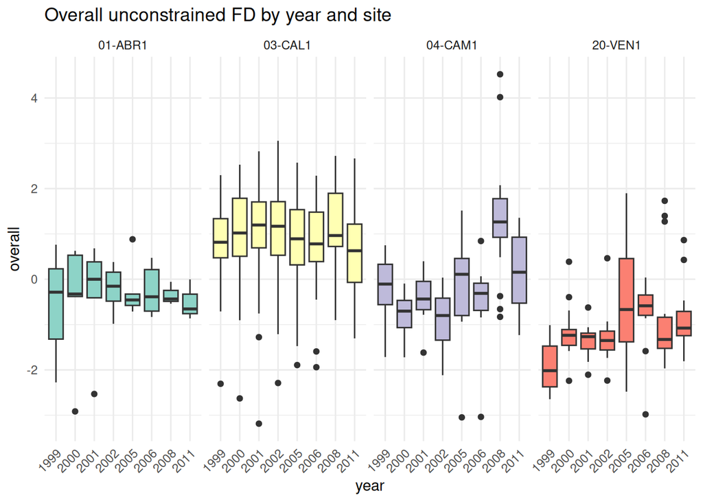

```r
results_all |>
  ggplot(aes(x = year, y = overall, fill = site)) +
  geom_boxplot() +
  scale_fill_brewer(type = "qual", palette = 8) +
  facet_wrap(~ site, nrow = 1) +
  theme_minimal() +
  theme(axis.text.x = element_text(angle = 45, hjust = 1),
        legend.position = "none")+
  ggtitle("Overall unconstrained FD by year and site")
```

All the trait groups:

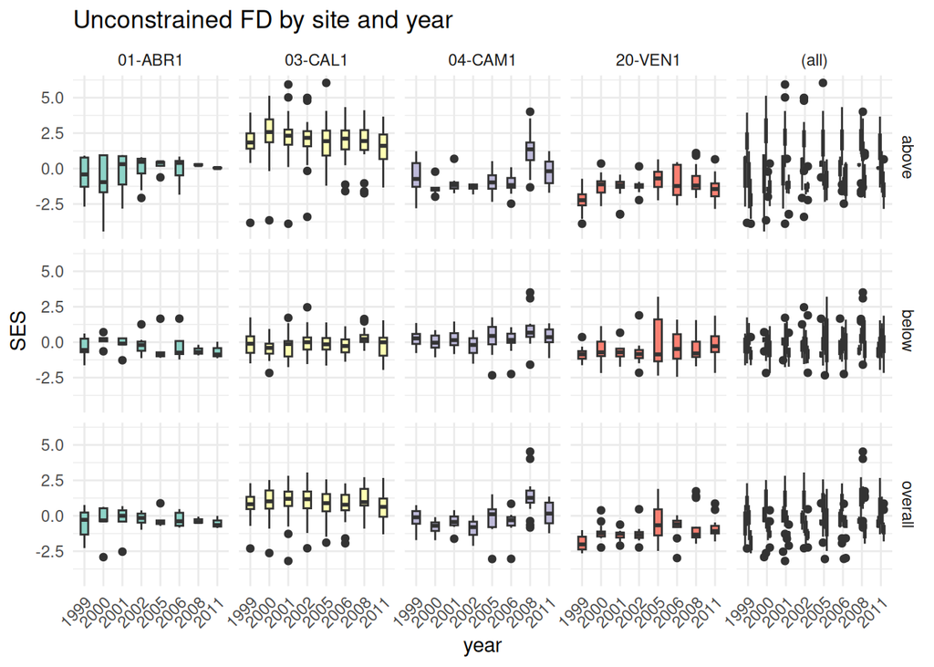

```r
results_all |>
  pivot_longer(overall:below, names_to = "traits", values_to = "SES") |>
  ggplot(aes(x = year, y = SES, fill = site)) +
  geom_boxplot(width = 0.4) +
  scale_fill_brewer(type = "qual", palette = 8) +
  facet_grid(vars(traits), vars(site), margins = "site") +
  theme_minimal() +
  theme(axis.text.x = element_text(angle = 45, hjust = 1),
        legend.position = "none")+
  ggtitle("Unconstrained FD by site and year")
```

## 7.2 Local species pool randomizations

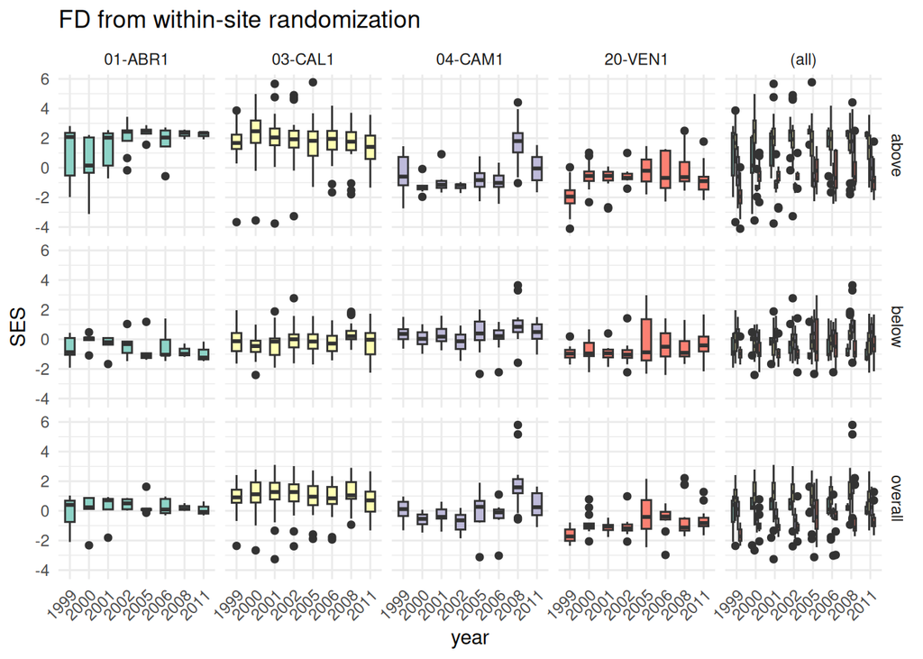

```r
results_sites |>
  pivot_longer(overall:below, names_to = "traits", values_to = "SES") |>
  ggplot(aes(x = year, y = SES, fill = site)) +
  geom_boxplot(width = 0.5, position = position_dodge2(padding = 0)) +
  scale_fill_brewer(type = "qual", palette = 8) +
  facet_grid(vars(traits), vars(site), margins = "site") +
  theme_minimal() +
  theme(axis.text.x = element_text(angle = 45, hjust = 1),
        legend.position = "none")+
  ggtitle("FD from within-site randomization")
```

## 7.3 Temporal species pool randomizations

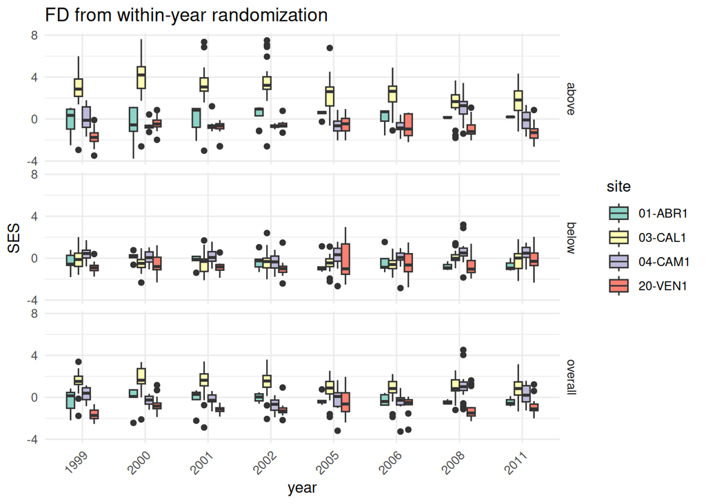

```r
results_years |>
  pivot_longer(overall:below, names_to = "traits", values_to = "SES") |>
  ggplot(aes(x = year, y = SES, fill = site)) +
  geom_boxplot(width = 0.5, position = position_dodge2(padding = 0)) +
  scale_fill_brewer(type = "qual", palette = 8, name = "site") +
  facet_grid(vars(traits)) +
  theme_minimal() +
  theme(axis.text.x = element_text(angle = 45, hjust = 1))+
  ggtitle("FD from within-year randomization")
```

# 8 Open-field weather models

The specification of these models refers to the DAGs.

## 8.1 Aboveground FD on air temperature and precipitation

Models for the total effect of air temperature, precipitation, and their interaction on aboveground FD-SES.

```r
fit_above_ofd <-  brm(above ~ air_t_mean_centered + precipitation_centered +
                              air_t_mean_centered:precipitation_centered + site,
                      data = ofd,
                      prior = prior,
                      file = "fits/fd/above.ofd",
                      seed = 2853)

prior_summary(fit_above_ofd)
```

| prior | class | coef | group | resp | dpar | nlpar | lb | ub | tag | source |
| --- | --- | --- | --- | --- | --- | --- | --- | --- | --- | --- |
| normal(0, 1) | b |  |  |  |  |  |  |  |  | user |
|  | b | air_t_mean_centered |  |  |  |  |  |  |  | default |
|  | b | air_t_mean_centered:precipitation_centered |  |  |  |  |  |  |  | default |
|  | b | precipitation_centered |  |  |  |  |  |  |  | default |
| student_t(3, 0, 0.7) | b | site1 |  |  |  |  |  |  |  | user |
| student_t(3, 0, 0.7) | b | site2 |  |  |  |  |  |  |  | user |
| student_t(3, 0, 0.7) | b | site3 |  |  |  |  |  |  |  | user |
| student_t(3, 0, 0.7) | Intercept |  |  |  |  |  |  |  |  | user |
| student_t(3, 0, 0.5) | sigma |  |  |  |  |  | 0 |  |  | user |

```r
fit_above_ofd
```

[output not shown]

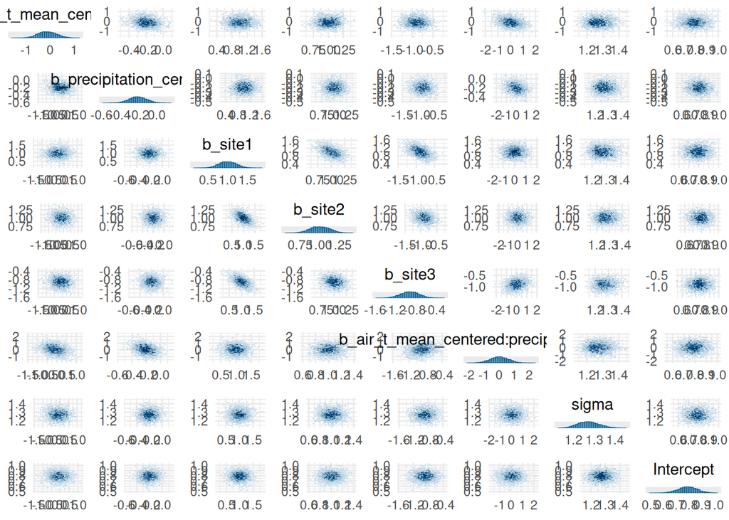

```r
my_mcmc_pairs(fit_above_ofd)
```

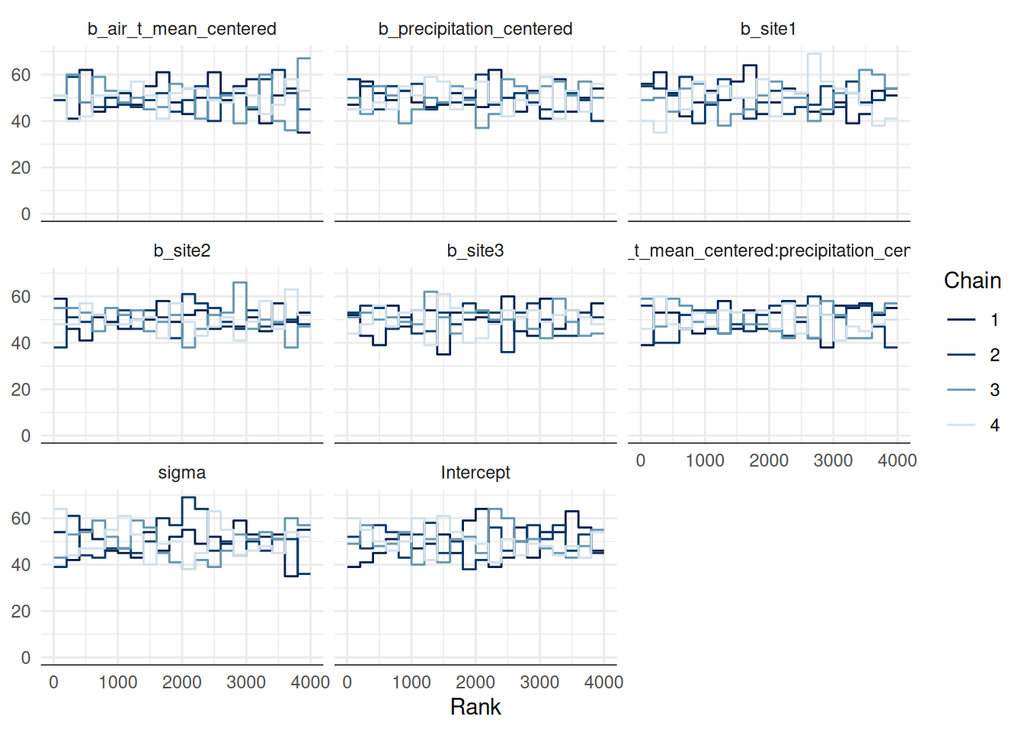

```r
trank(fit_above_ofd)
```

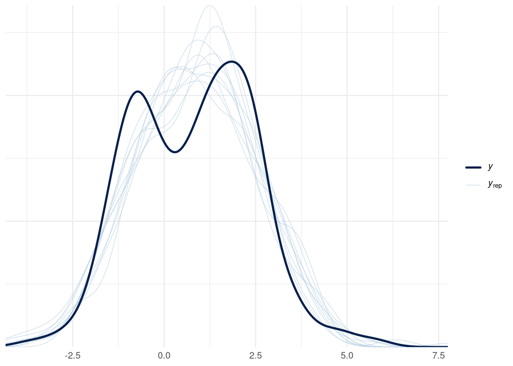

```r
pp_check(fit_above_ofd)
```

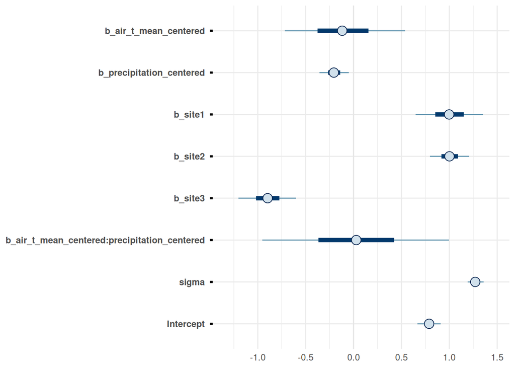

```r
mcmc_intervals(fit_above_ofd, pars = show)
```

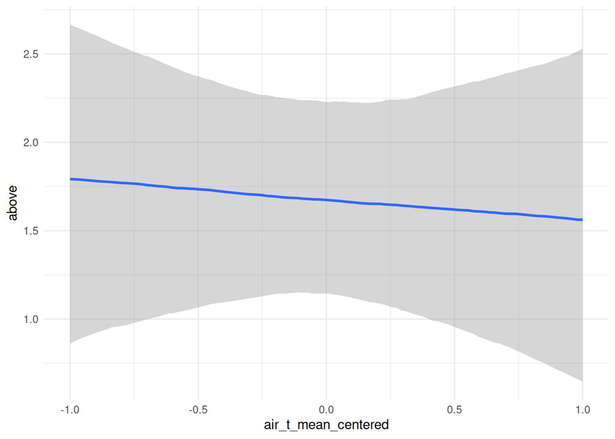

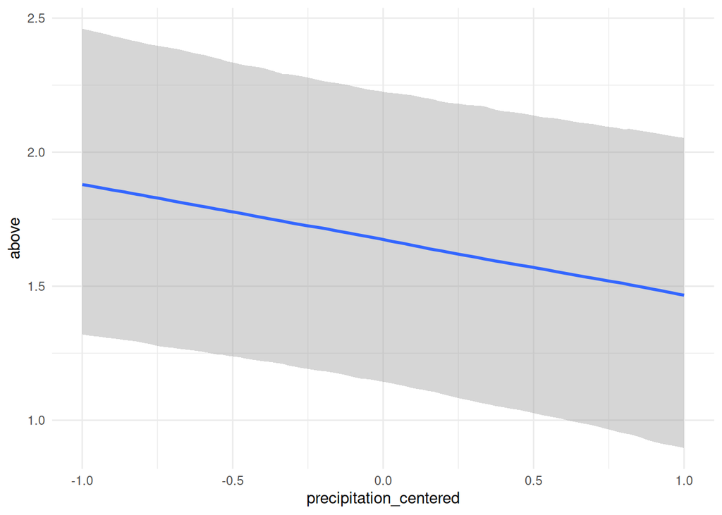

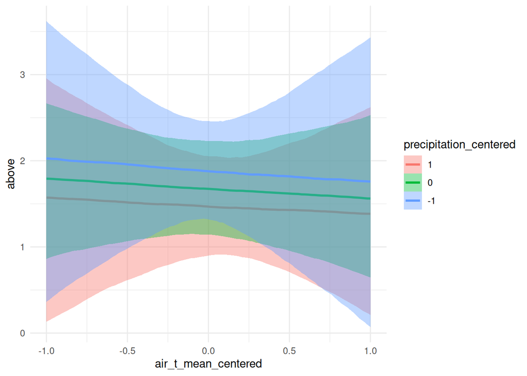

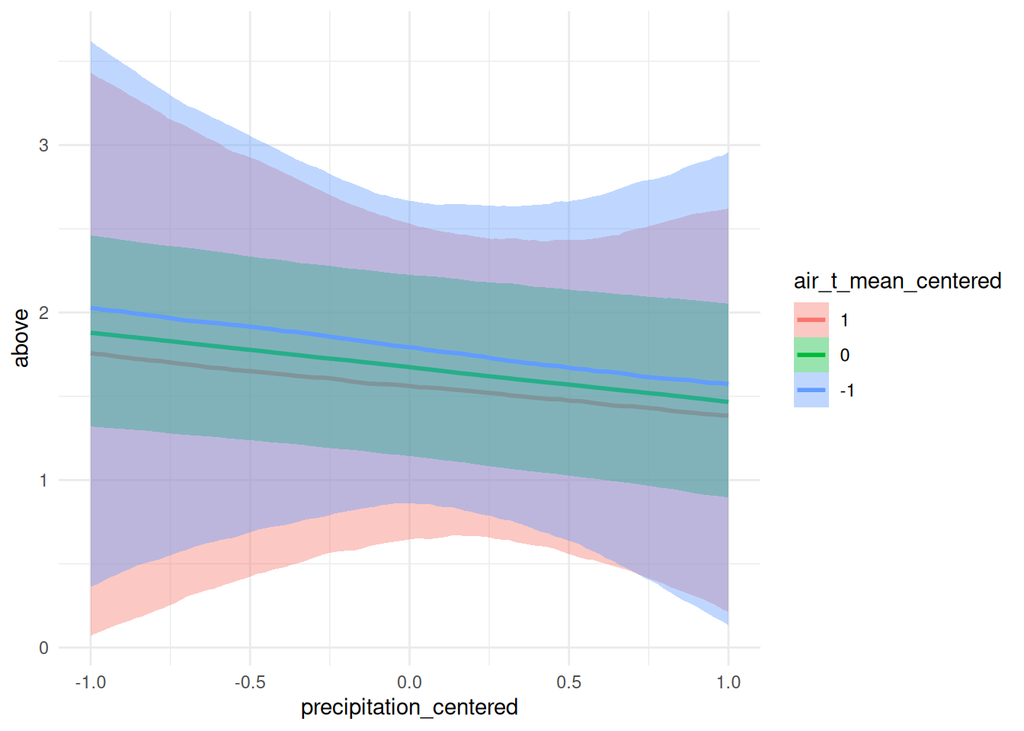

```r
my_ceffects(fit_above_ofd)
```